# Encuesta Nacional de Empleo: Indicadores de mercado laboral en Chile

## Encuesta Nacional de Empleo: Indicadores de mercado laboral en Chile

Brian Montenegro  
Sociólogo - Analista socioeconómico  
Instituto Nacional de Estadísticas  
3 de noviembre de 2026

Las opiniones y contenidos expresados en esta presentación son de exclusiva responsabilidad del autor y no representan necesariamente la posición institucional del Instituto Nacional de Estadísticas de Chile.

## Necesidades de información estadística

Como sociedad, necesitamos información para conocer y comprender la realidad en que vivimos. Las estadísticas oficiales cumplen un papel fundamental al proporcionar mediciones confiables, sistemáticas y comparables sobre los fenómenos económicos, sociales y demográficos que nos caracterizan.

¿Cuántos somos, cómo somos?

**Censo de Población y Vivienda**

¿Cuál es el estado de la seguridad ciudadana en el país?

**ENUSC** · Encuesta Nacional Urbana de Seguridad Ciudadana

¿Cuánto ganan las personas por su trabajo?

**ESI** · Encuesta Suplementaria de Ingresos

¿Cuál es la situación socioeconómica de los hogares en Chile?

**CASEN** · Encuesta de Caracterización Socioeconómica Nacional (MDSF)

¿Cuál es la situación del mercado laboral y de la ocupación en el país?

**ENE** · Encuesta Nacional de Empleo

## Objetivos de la ENE

La ENE es una **estadística oficial producida por el INE**, con origen en **1966**.

### Objetivo general

Clasificar y caracterizar a la **población en edad de trabajar según su condición de actividad**.

### Objetivos específicos

- Cuantificar personas ocupadas, desocupadas y fuera de la fuerza de trabajo.
- Caracterizar la inserción laboral de las personas ocupadas.
- Calcular las tasas de desocupación, ocupación y participación.

### Población y levantamiento

Personas de **15 años o más**, residentes habituales en viviendas particulares ocupadas en Chile.

Encuesta continua a una muestra de hogares; resultados mensuales por **trimestre móvil**.

Fuente: INE, Documento metodológico ENE, versión 2.0, abril de 2022. pp. 10, 12, 28 y 132.

## Indicadores del mercado laboral

julio–septiembre de 2026

9,8%

Tasa de desocupación nacional

De cada 100 personas en la fuerza de trabajo, cuántas están desocupadas.

### Ocupación y participación

Tasa de ocupación**55,5%**

De cada 100 personas de 15 años o más, cuántas tienen una ocupación.

Tasa de participación**61,6%**

De cada 100 personas de 15 años o más, cuántas integran la fuerza de trabajo.

Fuente: INE, Empleo trimestral N.º 336, 29 de octubre de 2026, p. 1.

## Proceso de producción estadística de la ENE

01

### Especificar necesidades

Información requerida sobre el mercado laboral.

02

### Diseñar

Conceptos, indicadores y cuestionario.

03

### Construir

Instrumentos, sistemas y procedimientos.

04

### Recolectar

Entrevistas a los hogares seleccionados.

05

### Procesar

Organización y preparación de la información.

06

### Analizar

Estimación y revisión de resultados.

07

### Difundir

Preparación y publicación de productos.

08

### Evaluar

Revisión de calidad y mejoras.

UNECE, Generic Statistical Business Process Model (GSBPM), versión 5.2.

## Recomendaciones internacionales y comparabilidad

02 · Diseñar

El INE utiliza recomendaciones estadísticas de la **Organización Internacional del Trabajo (OIT)** para medir con definiciones y criterios que permitan la comparación internacional.

| Conceptos | Qué se considera trabajo en la ocupación y desocupación, y qué actividades se incluyen en la medición. |
| --- | --- |
| Períodos de referencia | Trabajo: semana de referencia. Búsqueda: últimas cuatro semanas. Disponibilidad: dos semanas siguientes. |
| Criterios de clasificación | Condiciones que deben cumplirse para clasificar a una persona como ocupada, desocupada o fuera de la fuerza de trabajo. |

INE, Documento metodológico ENE, pp. 13–18 y 25–27. OIT, resolución de la 19.ª CIET (2013).

## El trabajo en la ocupación

02 · Diseñar

**La ocupación no es lo mismo que el empleo,** esto debido a que el empleo es una forma de ocupación. La ENE produce información sobre el **trabajo en la ocupación**.

### Trabajo

Actividades destinadas a producir bienes o prestar servicios para uso propio o de terceros.

### Trabajo en la ocupación

Trabajo para el mercado, a cambio de **remuneración o beneficio**.

INE, Documento metodológico ENE, pp. 14–18 y 22. Libro de códigos ENE, pp. 90–94.

## Condición de actividad de la población

02 · Diseñar

La población de 15 años o más se clasifica en tres grupos.

### Ocupados

- Al menos **una hora** en la semana de referencia.
- Trabajo **para el mercado**, por **remuneración o beneficio**.

**Ejemplo:** trabajó en una tienda durante la semana y recibirá un pago.

### Desocupados

- **Sin ocupación**.
- Búsqueda activa en las **últimas cuatro semanas**.
- Disponibilidad en las **dos semanas siguientes**.

**Ejemplo:** no tiene ocupación, envió currículums y está disponible para comenzar.

### Fuera de la fuerza de trabajo

No cumplen los criterios de ocupación ni desocupación.

**Ejemplos:**

- Estudia, no tiene ocupación y no busca empleo.
- No tiene ocupación, realiza cuidados, no busca y no está disponible.

Fuerza de trabajo (FT)

INE, Libro de códigos ENE, pp. 88–94. Documento metodológico ENE, pp. 14–20.

## Del concepto al cuestionario

02 · Diseñar

La **operacionalización** establece qué información debe recogerse para medir un concepto. Ejemplo: la ocupación.

| Aspecto de la definición | Información que debe recogerse | Preguntas |
| --- | --- | --- |
| Actividad laboral | Realización de trabajo y de actividades que podrían no reconocerse inicialmente como tal. | A1 y A2 |
| Período de referencia | Trabajo realizado durante la semana anterior a la entrevista. | Sección A |
| Remuneración o beneficio | Pago recibido o por recibir, en dinero o en especie. | A3 |

El cuestionario ordena las preguntas, define a quiénes se aplican y establece sus saltos.

INE, Documento metodológico ENE, pp. 14–18 y 25–27. Cuestionario ENE 2025, p. 8.

## Preguntas para identificar la ocupación

02 · Diseñar

### A1 · Actividad y período

[nombre de persona], la semana pasada, es decir, entre lunes y domingo, ¿trabajó por lo menos una hora?

1. Sí
2. No

Sí: pasa a A3.  
No: continúa en A2.

### A2 · Otras actividades

Independientemente de lo que acaba de decir, ¿hizo algún negocio, “pololo” u otra actividad por cuenta propia por lo menos durante una hora?

1. Sí
2. No

Indaga actividades que pueden no reconocerse inicialmente como trabajo.

### A3 · Remuneración

Por ese trabajo, ¿recibió o recibirá un pago en dinero o en especie?

1. Sí
2. No

El criterio de remuneración incluye pagos recibidos o por recibir.

INE, Cuestionario ENE 2025, p. 8, A1–A3.

## Preguntas para identificar la desocupación

02 · Diseñar

Para personas sin ocupación, se indagan la búsqueda de trabajo y la disponibilidad para comenzar.

### J1 · Búsqueda de trabajo

En las cuatro últimas semanas, hasta el domingo de la semana de referencia, ¿ha tratado de encontrar algún empleo o ha hecho alguna gestión para crear su propia empresa o negocio? Considere cualquier empleo aunque sea de unas pocas horas

1. Sí
2. No

Sí: continúa en J2, sobre gestiones de búsqueda.  
No: pasa a J7.

### J11 · Disponibilidad

Si durante la semana pasada hubiera encontrado un trabajo, ¿estaría disponible para comenzar a trabajar de este lunes que viene al otro?

1. Sí
2. No

Consulta la disponibilidad en las dos semanas siguientes.  
Sí: pasa a J13. No: continúa en J12.

INE, Cuestionario ENE 2025, pp. 16–17. Libro de códigos ENE, p. 89.

## Procesamiento de la información

05 · Procesar

Las respuestas de las entrevistas se organizan en una **base de datos**. El procesamiento revisa y prepara esa información para producir estadísticas.

### Reunir y organizar

Integrar los registros de viviendas, hogares y personas.

### Revisar la información

Comprobar que los registros estén completos y sean coherentes.

### Aplicar criterios comunes

Procesar las respuestas según las definiciones y reglas de la ENE.

INE, Documento metodológico ENE, capítulo 6.

## Preparación de las estimaciones

05 · Procesar

Los resultados describen a la población, a partir de una muestra de hogares.

### Registros de la muestra

Información individual organizada y revisada con las definiciones de la ENE.

### Factores de expansión

Permiten que cada registro represente a un conjunto de personas de la población.

Con esta información se estiman los totales de personas ocupadas, desocupadas y fuera de la fuerza de trabajo.

INE, Documento metodológico ENE, capítulos 4–6. Libro de códigos ENE, pp. 70–79.

## Estimación de las poblaciones laborales

06 · Analizar

Los factores de expansión permiten estimar cuántas personas hay en cada grupo a partir de la muestra entrevistada.

Población en edad de trabajar (PET)**16.699.158**

Fuerza de trabajo (FT)**10.282.718**

Ocupados (O)**9.274.742**

Desocupados (D)**1.007.976**

Población fuera de la fuerza de trabajo (PFFT)**6.416.440**

Fuente: INE, Empleo trimestral N.º 336, 29 de octubre de 2026, p. 1. Libro de códigos ENE, pp. 70–79.

## Cálculo de los indicadores laborales

06 · Analizar

FT = O + DPET = FT + PFFT

**Desocupación**TD = D / FT × 1009,8%

**Ocupación**TO = O / PET × 10055,5%

**Participación**TP = FT / PET × 10061,6%

O: ocupados · D: desocupados · FT: fuerza de trabajo · PET: población en edad de trabajar.  
PFFT: población fuera de la fuerza de trabajo.

INE, Libro de códigos ENE, pp. 70–71. Boletín ENE N.º336, p. 1.

## Evolución de la tasa de desocupación

06 · Analizar

Total país · trimestres móviles · sin ajuste estacional**Variación anual: +1,3 pp.**

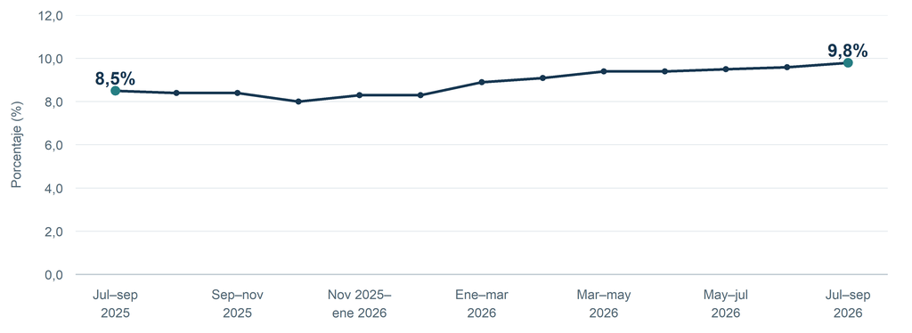

Fuente: INE, Empleo trimestral N.º 336, 29 de octubre de 2026, p. 1.

## Variaciones anuales de niveles y tasas

06 · Analizar

Julio–septiembre de 2026 respecto del mismo trimestre de 2025.

### Personas · variación porcentual

| Ocupadas | −1,1% |
| --- | --- |
| Desocupadas | +15,3% |
| Fuerza de trabajo | +0,3% |

### Tasas · puntos porcentuales

| Desocupación | +1,3 pp. |
| --- | --- |
| Ocupación | −1,1 pp. |
| Participación | −0,3 pp. |

La mayor desocupación se observa junto con una reducción de las personas ocupadas y un aumento de la fuerza de trabajo. La participación disminuye como proporción de la PET.

Fuente: INE, Empleo trimestral N.º 336, 29 de octubre de 2026, p. 1.

## Difusión de los resultados

07 · Difundir

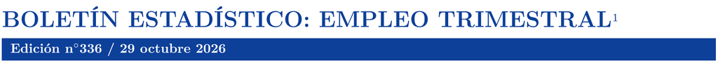

Cabecera original del boletín 336: título, edición y fecha de publicación.

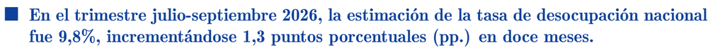

Resultado principal original: TD 9,8% y aumento de 1,3 puntos porcentuales en doce meses.

| Boletines | Presentan los principales resultados y sus variaciones. |
| --- | --- |
| Series y tabulados | Permiten comparar períodos y grupos de población. |
| Bases y documentación | Ofrecen información y definiciones para realizar otros análisis. |

INE, Boletín ENE N.º336, p. 1. Documento metodológico ENE, pp. 130–132.

## Información para conocer el mercado laboral

¿Cuál es la situación laboral del país?

La ENE produce información para conocer:

- La **magnitud de la ocupación y la desocupación**.
- La relación de la **población en edad de trabajar con la fuerza de trabajo**.
- Las **diferencias entre grupos y los cambios en el tiempo**.

La ENE construye conocimiento sobre el mercado laboral al precisar conceptos, traducirlos en preguntas y analizar la información con criterios de calidad. Ese proceso permite producir e interpretar resultados sobre la ocupación, la desocupación y la participación de la población.

INE, Documento metodológico ENE, capítulos 2 y 4–8.

## Situación del mercado laboral

Julio–septiembre de 2026

### Desocupación

**9,8%**

Personas desocupadas como proporción de la fuerza de trabajo.

+1,3 pp. en doce meses

### Ocupación

**55,5%**

Personas ocupadas como proporción de la población de 15 años o más.

−1,1 pp. en doce meses

### Participación

**61,6%**

Personas en la fuerza de trabajo como proporción de la población de 15 años o más.

−0,3 pp. en doce meses

En comparación con el mismo trimestre de 2025, aumentó la desocupación y disminuyeron las tasas de ocupación y participación.

Fuente: INE, Empleo trimestral N.º 336, 29 de octubre de 2026, p. 1.

## Referencias

### Documentos de la ENE

- **INE (2022).** Documento metodológico de la ENE. Versión 2.0, abril de 2022.
- **INE (2026).** Empleo trimestral N.º 336. Julio–septiembre de 2026.
- **INE (2026).** Libro de códigos de la ENE. Julio de 2026.
- **INE (2025).** Cuestionario de la ENE.

### Recomendaciones y productos estadísticos

- **OIT (2013/2023).** [Resolución sobre estadísticas del trabajo, la ocupación y la subutilización de la fuerza de trabajo](https://www.ilo.org/resource/resolution-concerning-statistics-work-employment-and-labour).
- **UNECE (2025).** [GSBPM, versión 5.2](https://unece.org/statistics/gsbpm-v5.2).
- **INE.** [Censo de Población y Vivienda](https://censo2024.ine.gob.cl/todo-sobre-el-censo/).
- **INE.** [Encuesta Nacional Urbana de Seguridad Ciudadana](https://www.ine.gob.cl/estadisticas-por-tema/sociedad-y-condiciones-de-vida/seguridad-ciudadana/informacion-de-la-encuesta).
- **INE.** [Encuesta Suplementaria de Ingresos](https://www.ine.gob.cl/estadisticas-por-tema/mercado-laboral/encuesta-suplementaria-de-ingresos).
- **MDSF.** [Encuesta de Caracterización Socioeconómica Nacional](https://observatorio.ministeriodesarrollosocial.gob.cl/encuesta-casen).

## ¡Gracias!

Brian Montenegro  
Instituto Nacional de Estadísticas